# Computer Science 1

**Computer lab 11**

**Course Number:** BTPS1210BA-E  
**Contact Information:** Please contact me through email anytime: abari.kalman@arts.unideb.hu

Author

Kálmán Abari

Published

September 5, 2026

Learning outcomes

Students will learn how to create a presentation in PowerPoint.

# Presentation: PowerPoint

## Problem 1

> In this section, you will learn how to create a simple presentation in PowerPoint.

PowerPoint presentations work like slide shows. To convey a message or a story, you break it down into slides. Think of each slide as a blank canvas for the pictures and words that help you tell your story. [Basic tasks](https://support.microsoft.com/en-us/office/basic-tasks-for-creating-a-powerpoint-presentation-efbbc1cd-c5f1-4264-b48e-c8a7b0334e36) for creating a PowerPoint presentation are very easy. [Creating presentation](https://support.microsoft.com/en-us/office/create-a-presentation-in-powerpoint-422250f8-5721-4cea-92cc-202fa7b89617) we will focus on the followings:

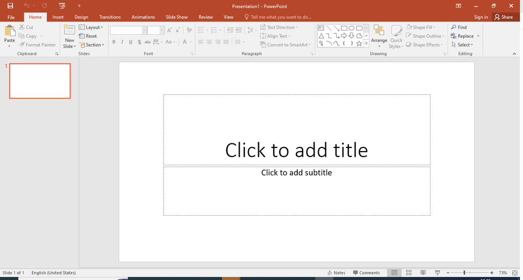

New blank presentation

2. Download a zip file from [here](https://github.com/abarik/computer_science_1_2023_24_1/blob/6bf588fa88e5fb68e76fabb9e6e50e02bec48413/files/misc_lab11_1.zip). The zip file contains the text of the presentation and the 3 required images. Unzip and open the file `text_form_slides.txt` in a simple text editor (e.g. Notepad).
3. From the `text_form_slides.txt` file, use a clipboard to copy the title and name from the ‘Title Slide’ part.

[figure not shown]

Title Slide

4. Insert a new slide: `Home / New Slide / Two Content`.

[figure not shown]

Insert a new slide with two content

[figure not shown]

A new slide with two content

5. From the `text_form_slides.txt` file, use a clipboard to copy the title and content from the ‘Slide 1:’ part. Modify the text (delete unnecessary characters), [add bullets, and sub-bullets](https://support.microsoft.com/en-us/office/add-text-bullets-and-sub-bullets-152f4879-775e-47d0-81c9-4eee39171b2a).

[figure not shown]

Slide 1 with text

6. Insert picture `pict_01.jpg` from the unzipped folder.

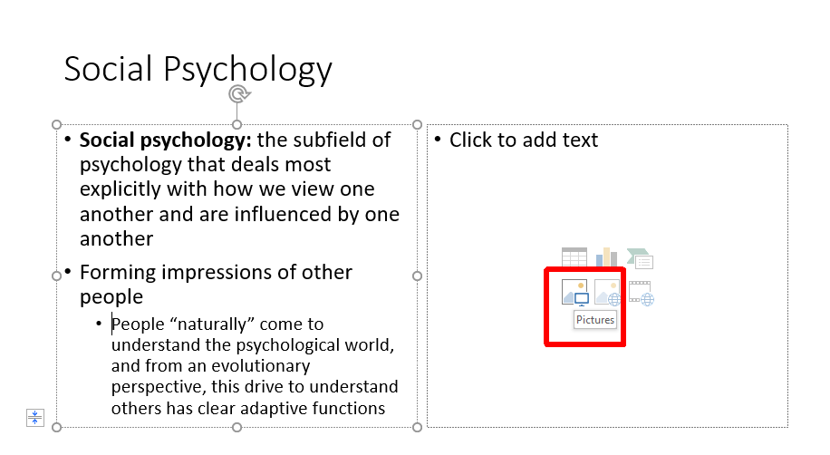

Insert a picture

[figure not shown]

Slide 1 with text and picture

7. Insert a new slide: `Home / New Slide / Title and Content`.

[figure not shown]

Insert a new slide with title and content

[figure not shown]

A new slide with title and content

8. From the `text_form_slides.txt` file, use a clipboard to copy the title and content from the ‘Slide 2:’ part. Modify the text (delete unnecessary characters), [add bullets](https://support.microsoft.com/en-us/office/add-text-bullets-and-sub-bullets-152f4879-775e-47d0-81c9-4eee39171b2a).

[figure not shown]

Slide 2

9. Insert a new slide: `Home / New Slide / Two Content`.

[figure not shown]

Insert a new slide with two content

[figure not shown]

New slide with two content

10. From the `text_form_slides.txt` file, use a clipboard to copy the title and content from the ‘Slide 3:’ part. Modify the text (delete unnecessary characters), [add bullets, and sub-bullets](https://support.microsoft.com/en-us/office/add-text-bullets-and-sub-bullets-152f4879-775e-47d0-81c9-4eee39171b2a).

[figure not shown]

Slide 3 with text

11. Insert picture `pict_02.jpg` from the unzipped folder.

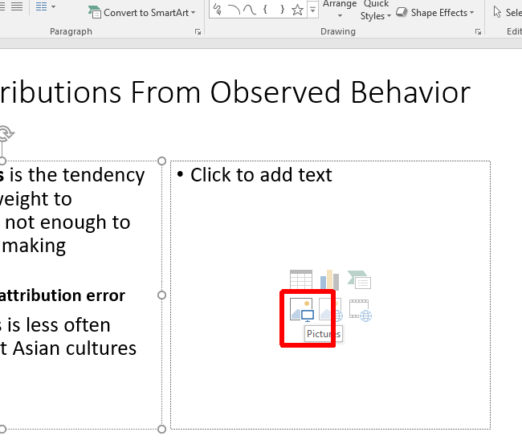

Insert a new picture

[figure not shown]

Slide 3 with text and picture

12. Insert a new slide: `Home / New Slide / Title and Content`. From the `text_form_slides.txt` file, use a clipboard to copy the title from the ‘Slide 4:’ part.

[figure not shown]

Insert a new slide with title and content

[figure not shown]

A new slide with text

13. Insert picture `pict_03.png` from the unzipped folder.

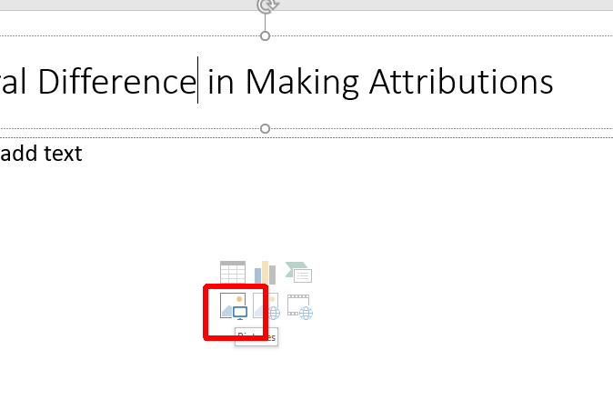

Insert a new picture

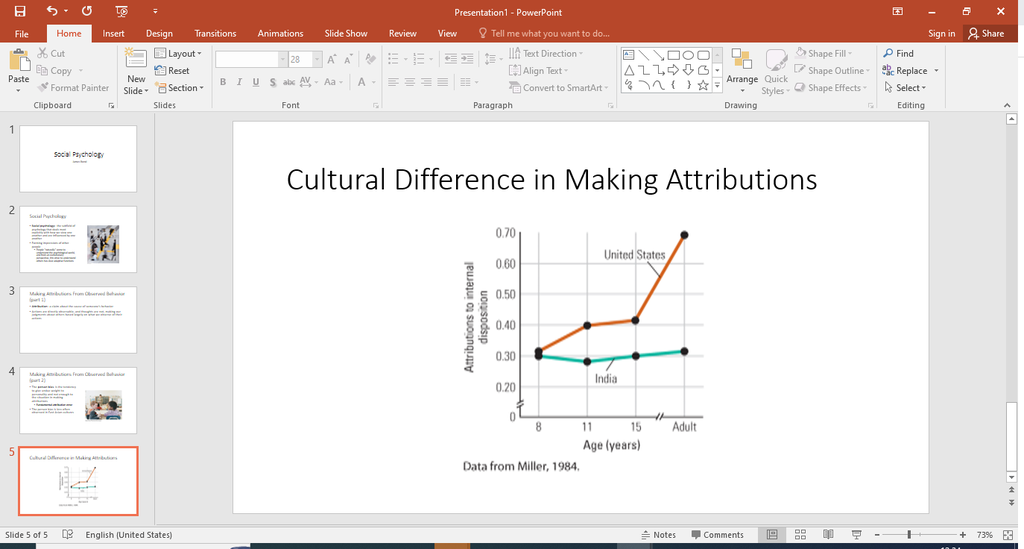

A new slide with text and picture

14. Insert a new slide: `Home / New Slide / Title and Content`.

[figure not shown]

Insert a new slide with title and content

[figure not shown]

A new slide with title and content

15. From the `text_form_slides.txt` file, use a clipboard to copy the title and content from the ‘Slide 5:’ part. Modify the text (delete unnecessary characters), [add bullets](https://support.microsoft.com/en-us/office/add-text-bullets-and-sub-bullets-152f4879-775e-47d0-81c9-4eee39171b2a).

[figure not shown]

Slide 5

16. Insert a new slide: `Home / New Slide / Section Header`.

[figure not shown]

Insert a new slide with section header

[figure not shown]

A new slide with section header

17. From the `text_form_slides.txt` file, use a clipboard to copy the title and content from the ‘Slide 6:’ part.

[figure not shown]

Slide 6

18. Add new footer to all slides. Select `Insert / Header & Footer` button.

[figure not shown]

Add footer button

19. Add text ‘James Bond, University of Debrecen, Psychology BA’ to the footer, and switch on ‘Slide number’ and ‘Do not show on title slide’ check boxes.

[figure not shown]

Add footer and slide number

[figure not shown]

Slides with footer and slide number

20. Apply Restrospect Theme on presentation. Select `Design / Theme / Restrospect` button.

[figure not shown]

Apply Restrospect Theme

21. Save and send your `social_psychology_01.pptx` to the `abari.kurzus@gmail.com`. The subject of this email is `Lab11 - Problem 1`.

## Problem 2

> In this section, you will learn how to apply your presentation skills to produce a complete, publication-ready presentation.
1. Create a new PowerPoint presentation based on the [downloadable PDF file](https://github.com/abarik/computer_science_1_2023_24_1/blob/c4f9f29790052b574cde3cec5c1e5398e3030359/files/presentation_02.pdf). The content of the presentation should be the same as the PDF file and the look should be similar to the PDF file.
2. Save and send your `presentation_02.pptx` to the `abari.kurzus@gmail.com`. The subject of this email is `Lab11 - Problem 2`.